# Lecture 9 — R Graphics and Statistics: Making Data Talk

Statistics and Graphics: From Counts to Conclusions

Fighting Cancer with Transcriptomics 2026

2026-11-02

## 📊 From Counts to Conclusions

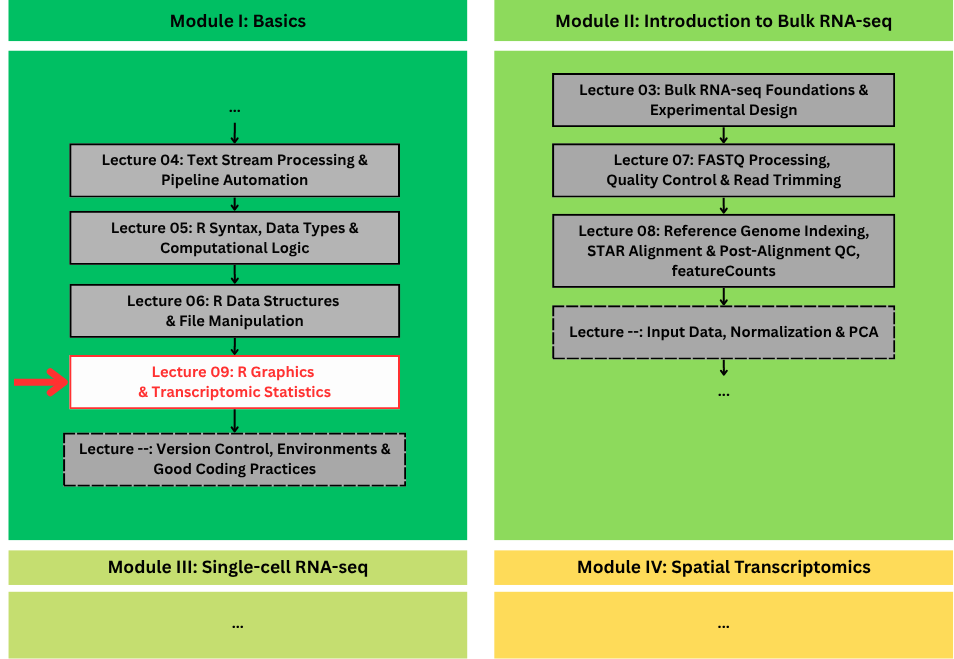

## 🗺️ Where Lecture 9 sits

- **Lectures 1, 2, 4**: course intro, Linux, text streams, pipelines
- **Lectures 5, 6**: R syntax, data types, data structures — the R track
- **Lectures 3, 7, 8**: bulk RNA-seq — design, FASTQ QC, STAR alignment, featureCounts
- **Lecture 9: R Graphics & Transcriptomic Statistics** — statistics that turn numbers into claims, plots that show them.

## 1. Review from Lecture 8

**1. Review from Lecture 8**

2. Descriptive Statistics

3. Shape, Distribution & Normality

4. p-value & Statistical Tests

5. Correlation & Regression

6. Statistics Practice

7. From Numbers to Figures

8. The Common Plots

9. Reading a ggplot2 Call

10. Export for Publication

11. Graphics Practice

1. Review from Lecture 8

### ⚡ Q1: Find the counts for gene `X` — which line gets the row?

- **A.** `df[2, ]`
- **B.** `df[3, ]`
- **C.** `df[, 2]`
- **D.** `df$X`

1. Review from Lecture 8

### ✅ **B** — `df[3, ]` is the whole row for gene `X`

- **A** is the **2nd row** — `BRCA1`, not `X`. The comma is right; the number is the wrong gene.
- **C** is the **2nd column** as a vector: `1200 450 89`. The comma comes *before* the `2`.
- **D** is the **quiet trap**: `$` takes a *column by name*, and there is no column called `X`, so it returns `NULL` with no error.

**Tip**

The way you do it in real code: `df[df$gene == "X", ]`. Row names are not row numbers, so index by a condition.

A data frame gives you a row only when the **comma** is there: `[row, column]`

1. Review from Lecture 8

### ⚡ Q2: Which line gets the counts, not the wrapper?

- **A.** `qc_report["umi_counts"]`
- **B.** `qc_report[["umi_counts"]]`
- **C.** `qc_report$sample_name`
- **D.** `qc_report[1]`

1. Review from Lecture 8

### ✅ **B** — `[[ ]]` unwraps, `[ ]` keeps the wrapper

- **A** single brackets keep the wrapper: the printout starts with `$umi_counts`, then the numbers.
- **C** `$` picks by name, and `sample_name` is a string: `chr "Visium_HD_01"`, not the counts.
- **D** `[1]` picks by position *and* keeps the wrapper: `List of 1` with `$sample_name`.

**Note**

Use `[[ ]]` when you want the value, `[ ]` when you want a smaller list.

`str()` shows the difference immediately.

1. Review from Lecture 8

### ⚡ Q3: Which line averages only the measured spots?

- **A.** `mean(umi, rm.na = TRUE)`
- **B.** `mean(umi, na.rm = TRUE)`
- **C.** `mean(!is.na(umi))`
- **D.** `mean(umi, na.rm = NA)`

1. Review from Lecture 8

### ✅ **B** — the flag is spelled `na.rm`, and it must be `TRUE`

- **A** `mean()` reads `na.rm`. `rm.na` lands in `...` and is ignored, so the `NA` stays and the result is `NA`.
- **C** `!is.na(umi)` is a logical vector: `TRUE TRUE FALSE TRUE TRUE`. Averaging it gives the *share* of measured spots, `0.8`, not the counts.
- **D** the flag has to be `TRUE`. `isTRUE(NA)` is `FALSE`, so nothing is dropped and the answer stays `NA`.

Count the holes first, then decide. `na.rm = TRUE` is a choice you report, not a default.

1. Review from Lecture 8

### A number means nothing on its own

A p-value, not a p-list.

— the statistician’s rule of thumb, on this deck’s own theme

One count answers one question. Statistics is what lets us say:

- what the data **looks like** (descriptive)
- what the data is **likely to be** (distribution)
- what we can **claim** from it (inference)

Today: 8 tools, in the order you use them.

1. Review from Lecture 8

### 🧰 The statistician’s toolbox

1. **Describe**: mean, median, sd, IQR
2. **Observe the shape**: is it a normal distribution?
3. **Check normality**: Shapiro-Wilk, Q-Q plot
4. **Choose a test**: parametric or non-parametric
5. **Read the p-value**
6. **Correct for multiple testing**
7. **Correlate and regress**
8. **Plot it** — devices, ggplot2, publication figures

## 2. Descriptive Statistics

1. Review from Lecture 8

**2. Descriptive Statistics**

3. Shape, Distribution & Normality

4. p-value & Statistical Tests

5. Correlation & Regression

6. Statistics Practice

7. From Numbers to Figures

8. The Common Plots

9. Reading a ggplot2 Call

10. Export for Publication

11. Graphics Practice

2. Descriptive Statistics

### 🎯 The problem: seven spots — how do you describe them?

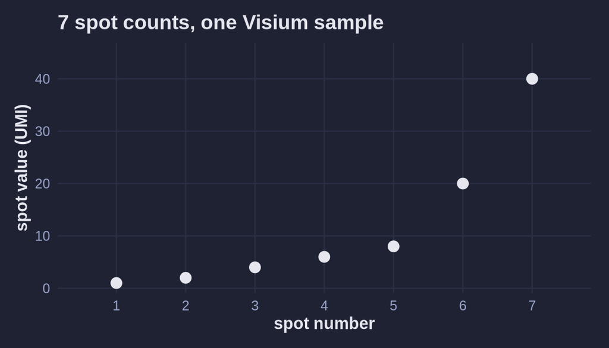

- **what’s the range of our data?** — the span
- **what is a typical spot?** — the average
- **how spread out are the counts?** — the spread

2. Descriptive Statistics

### The Range — min to max

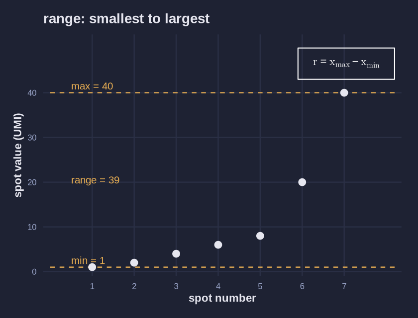

2. Descriptive Statistics

### The Center — where the middle is

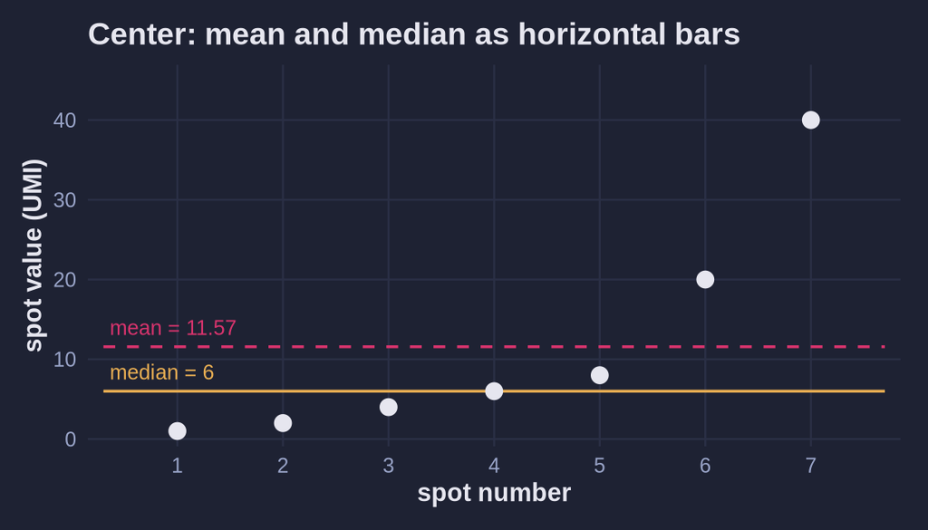

- **mean**: add them, divide by how many
- **median**: the middle value, after sorting

2. Descriptive Statistics

### Quartiles — the median of each half

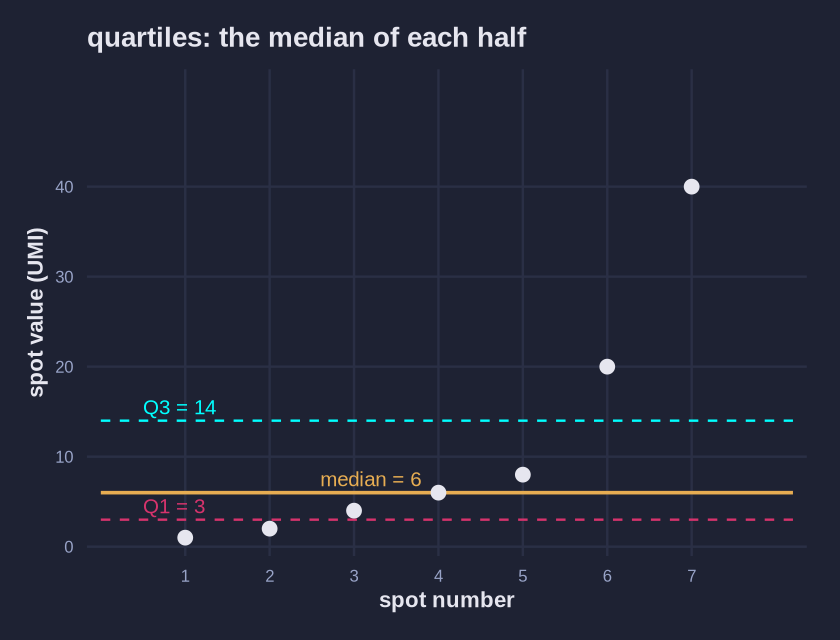

- **Q1**: the median of the lower half
- **Q3**: the median of the upper half

> Two ways to choose the halves. **Keeping the median** in both halves gives 3 and 14 — what R’s `quantile()`, `fivenum()` and `boxplot()` report. **Excluding the median** is the calculator rule: lower half 1, 2, 4 → 2, upper half 8, 20, 40 → 20.

2. Descriptive Statistics

### Interquartile range (IQR) — the middle half

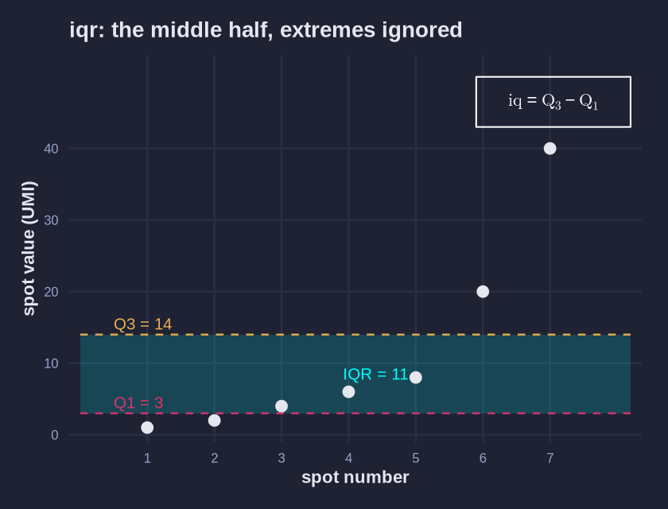

- **Q1**: the lowest 25% of the spots
- **Q3**: the highest 25% of the spots
- **IQR**: Q3 − Q1 — the spread of the middle half

2. Descriptive Statistics

### The Spread — how far it is from the center

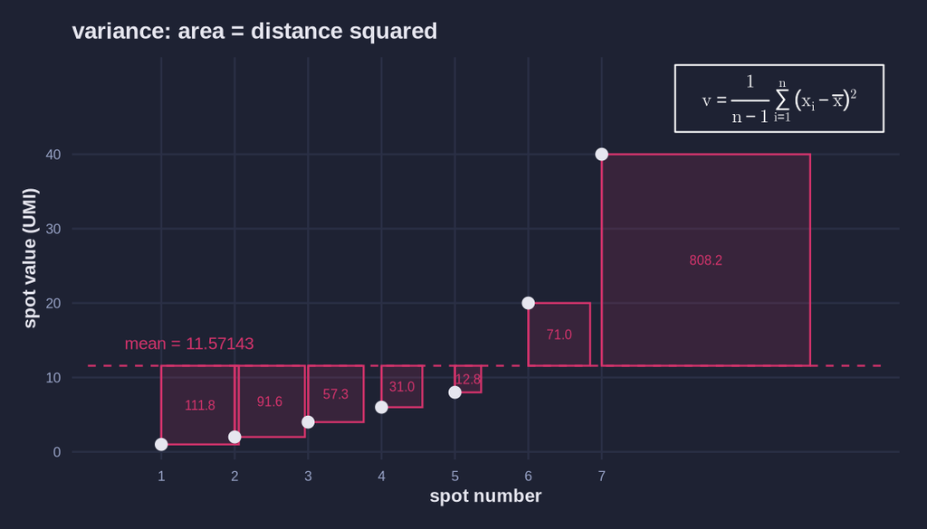

2. Descriptive Statistics

### Variance — spread distance in squared units

$$v = \frac{1}{n-1}\sum_{i=1}^{n}(x_i - \bar{x})^2$$

Why variance?

- **Tests** need variance: t-tests, DE models,…
- Make counts usable for **clustering** and **PCA**.
- Variable-gene step uses genes with the **highest variance**

2. Descriptive Statistics

### 📏 Standard deviation — the deviation from the mean

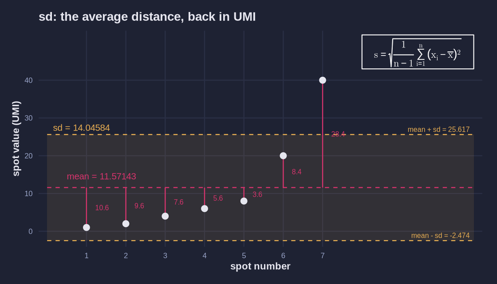

2. Descriptive Statistics

### 📏 sd — the average distance from the mean

$$s = \sqrt{\frac{1}{n-1}\sum_{i=1}^{n}(x_i - \bar{x})^2}$$

Why standard deviation?

- **the typical range** — sd sets the band `mean − sd` to `mean + sd`; inside = typical, outside = stands out → **p-value**
- **the summary table** — every group reports **mean ± sd**, and **Shapiro-Wilk** tests the normal distribution sd defines

2. Descriptive Statistics

### 🔍 variance vs sd — same information, two units

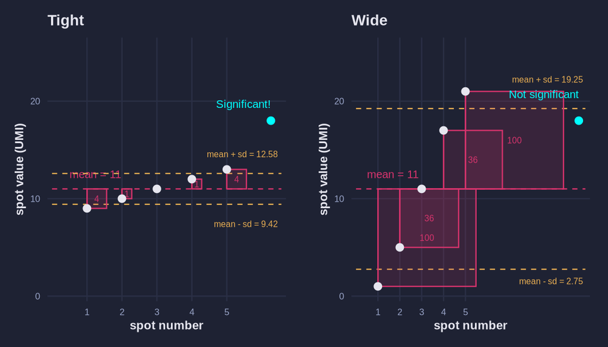

**⚖️ sd is what decides a claim**

2. Descriptive Statistics

### ⚡ Q1: Seven tumor spots, mean 11.57. You want one number saying how typical a spot is, in UMI counts. Which?

- **A.** `var(counts)`
- **B.** `sd(counts)`

2. Descriptive Statistics

### ✅ **B** — sd is the spread in the **same units as the counts**

- **B** sd is in counts, so `mean ± sd` is a band the reader can check against the dots.
- **A** variance is squared counts — for tests and models, not for reporting.

Report the sd, keep the variance for the model.

2. Descriptive Statistics

### ⚡ Q2: `mean(tight)` and `mean(wide)` are both 11. Which line shows the groups are different?

- **A.** `median(tight)` vs `median(wide)`
- **B.** `sd(tight)` vs `sd(wide)`
- **C.** `length(tight)` vs `length(wide)`
- **D.** `sum(tight)` vs `sum(wide)`

2. Descriptive Statistics

### ✅ **B** — same centre, five times the spread

- **A** both medians are 11, so the middle does not tell the groups apart.
- **C** both groups have 5 spots; the same n says nothing about spread.
- **D** both sums are 55, so the total is identical too.
- **B** sd is the only number that separates them: a tight group is repeatable, a wide group is *noisy*

**Note**

The mean is the same number; the data is not the same data.

2. Descriptive Statistics

### ⚡ Q3: One 500 joins nine small counts. Which number moves most?

- **A.** the median
- **B.** the mean
- **C.** both move by the same amount
- **D.** neither: the centre is fixed

2. Descriptive Statistics

### ✅ **B** — the mean carries 500, the median ignores its size

- **A** the median sees only the middle two positions: 6.5.
- **C** the mean absorbs 500, the median gains nothing — not symmetric.
- **D** the centre moves by 48.9. That gap is the finding.
- **B** the mean adds every value, so 500 enters as 500 / 10 = 50 per spot.

**Tip**

**Report both.** If mean and median sit far apart, that gap is the finding.

2. Descriptive Statistics

2. Descriptive Statistics

### ✅ Summary

- **three questions**: the span, the typical spot, the spread
- **range** = min to max · **mean** = add and divide · **median** = middle
- **quartiles** = median of each half · **IQR** = the middle 50%
- **variance** = squared units, for tests · **sd** = the data’s units, for reporting
- **mean + median together** show the shape — one outlier moves the mean
- **summary()** prints the whole set

## 3. Shape, Distribution & Normality

1. Review from Lecture 8

2. Descriptive Statistics

**3. Shape, Distribution & Normality**

4. p-value & Statistical Tests

5. Correlation & Regression

6. Statistics Practice

7. From Numbers to Figures

8. The Common Plots

9. Reading a ggplot2 Call

10. Export for Publication

11. Graphics Practice

3. Shape, Distribution & Normality

### 🎯 The problem: same mean, three different tumors

Three tumors can have the same average UMI count and be completely different data.

3. Shape, Distribution & Normality

### 🧐 sd ranks the spread, not the shape

- sd sorts the three by spread: `tumor2` widest, `tumor3` tightest.
- sd is one number — how far the counts sit from the mean, not **where** they sit.
- `tumor3` has a tail to the left, and sd only reports that it is tight.

**So what should we do?**

3. Shape, Distribution & Normality

### The shape is the information

It matters because the most common tests **assume** this shape. If the data is normally distributed, those tests work. If it is not, those tests can lie.

**Note**

UMI counts are usually **not** normally distributed: many low-count spots, a few very high ones. Long tail on the right.

3. Shape, Distribution & Normality

### Symmetric — `tumor1`

Many measurements pile up in the middle and thin out evenly on both sides.

That shape is called **normal** — the bell curve.

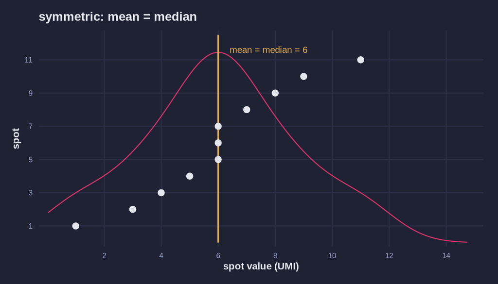

- the counts sit evenly on both sides of the middle
- **mean ≈ median** — the two lines land on the same spot

3. Shape, Distribution & Normality

### Right-skewed — `tumor2`

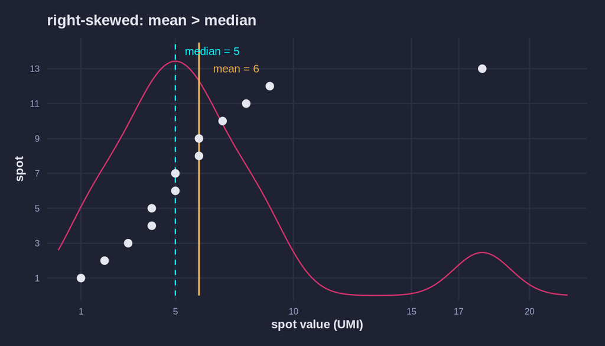

- twelve counts climb from 1 to 9, one count sits far above
- the high count drags the mean up — the median stays with the pile
- **mean > median**

3. Shape, Distribution & Normality

### Left-skewed — `tumor3`

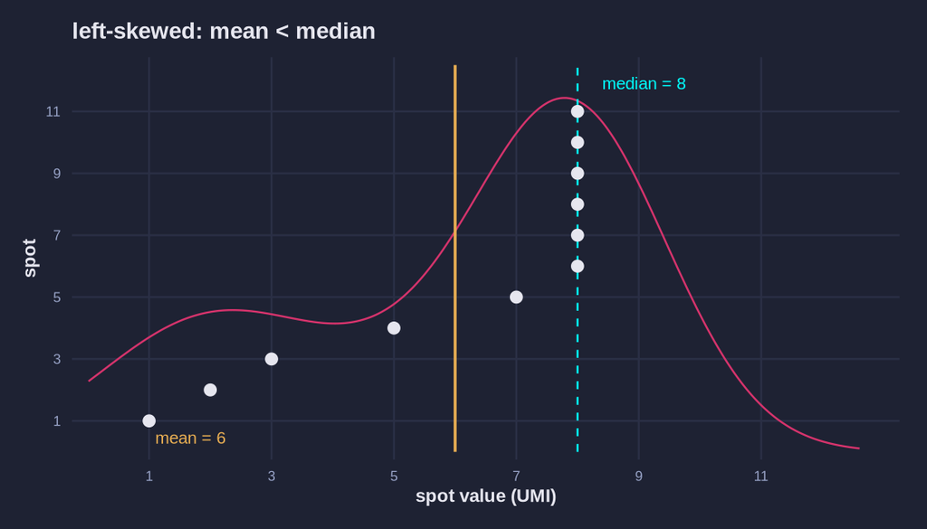

3. Shape, Distribution & Normality

### Shapiro-Wilk test

One number, one p-value:

- **p > 0.05** → no **evidence against normal**. Treat it as a **normal distribution**.
- **p ≤ 0.05** → the data is **not normal**. **Do not use normal-distribution tests.**

**Note**

A Q-Q plot is the visual version: points curving away at the end mean a real tail.

3. Shape, Distribution & Normality

### A Q-Q plot

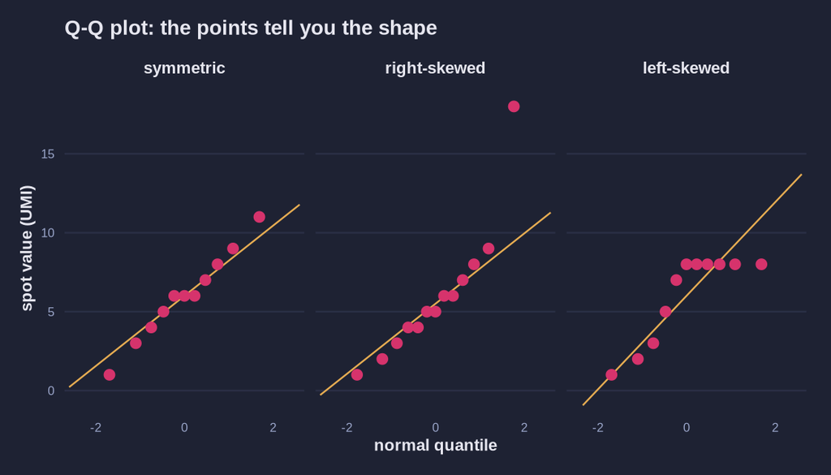

**Read the shape from the plot** before choosing a test.

3. Shape, Distribution & Normality

### ✅ Summary

- sd ranks the **spread**, not the **shape**
- shape = mean vs median: **mean ≈ median** symmetric · **mean > median** right · **mean < median** left
- the common tests **assume** the normal shape — UMI counts are usually right-skewed
- Shapiro-Wilk gives the number, the Q-Q plot the picture — same check
- p > 0.05 → treat as normal · p ≤ 0.05 → not normal, use the rank test

## 4. p-value & Statistical Tests

1. Review from Lecture 8

2. Descriptive Statistics

3. Shape, Distribution & Normality

**4. p-value & Statistical Tests**

5. Correlation & Regression

6. Statistics Practice

7. From Numbers to Figures

8. The Common Plots

9. Reading a ggplot2 Call

10. Export for Publication

11. Graphics Practice

4. p-value & Statistical Tests

### What a p-value is

> …the **p-value** is the **probability** of obtaining test results **at least as extreme as the result** actually observed, under the assumption that the null hypothesis is correct.

[figure not shown]

FB: @Statisticss · IG: @StatisticsForYou — image via Google Images ([thumbnail source](https://encrypted-tbn0.gstatic.com/images?q=tbn:ANd9GcRXpp3pINnzFSvCjsztyHpUuEUrASfQBQ7KrqcRq2yvQBfF1ofyayYX-v_O&s=10))

**Important**

p is **not** the probability the hypothesis is true.

It answers “*what are the chances of getting a result this extreme by pure randomness?*”.

4. p-value & Statistical Tests

### p from 0.5 down to 0.001

- p = 0.5 → this result is common under no effect. Not evidence.
- p = 0.1 → 1 in 10 under no effect. Not evidence.
- **p = 0.05** → the decision line. 5 in 100 under no effect.
- p = 0.03 → if the groups were truly the same, this happens about 3 times in 100
- p = 0.01 → 1 in 100 under no effect.
- p = 0.001 → 1 in 1,000 under no effect.

4. p-value & Statistical Tests

### ⚠️ The problem: 20,000 genes

- A gene with no difference still gets a p-value. p is defined under no effect, so a result this extreme happens 5 times in 100.

Test 20,000 genes at p < 0.05, and **1,000 will pass by chance alone**. Not good.

**Important**

Every transcriptomics analysis tests thousands of features. Without a correction, you are not discovering — you are sorting noise.

4. p-value & Statistical Tests

### The new threshold — Why divide by 20,000?

- 0.05 = 1 in 20 fluke chance for one test
- 20,000 = number of tests
- 1 in 20 ÷ 20,000 = 1 in 400,000: the whole analysis keeps 1 in 20

4. p-value & Statistical Tests

### Bonferroni — strict

**Tip**

Simple BUT **very hard to pass**.

It kills real findings too.

4. p-value & Statistical Tests

### Benjamini-Hochberg — the usual choice

Control the **false discovery rate** (FDR): the share of your “significant” list that is noise.

**Important**

**BH** is the **standard** in transcriptomics.

4. p-value & Statistical Tests

### Where do p-values come from?

p is not a number you choose. It is the **output of a test**.

Two decisions come before the test:

- **The unit** — what varies independently
- **The test** — the question, and the shape of the data

4. p-value & Statistical Tests

### ⚠️ The problem: 80 spots, 4 patients

The question: **is this gene higher in tumor?**

The data we have is spots. The claim we want is about patients.

4. p-value & Statistical Tests

### Every test in the book

- Student t
- Welch t
- paired t
- Wilcoxon
- Wilcoxon signed-rank
- sign test
- bootstrap
- permutation
- ANOVA
- Welch ANOVA
- Kruskal-Wallis
- Friedman
- MANOVA
- chi-square
- Fisher
- G-test
- Poisson
- negative binomial
- Pearson
- Spearman
- Kendall
- linear regression
- logistic regression
- Levene
- Bartlett
- Fligner
- Kolmogorov-Smirnov
- DESeq2
- edgeR
- limma-voom
- …

**Note**

Every name is a valid test. Most of them do not answer this question, and the question itself does not say which one to run.

4. p-value & Statistical Tests

### An example

**p-value = 1.772e-07 — far below 0.05, so the result is significant. Means 26.200 vs 20.125, a difference of 6.075.**

You reported this gene expressed **MORE** in tumor cohorts.

4. p-value & Statistical Tests

### In reality, the pooled p is a pitfall

Patient 1 and patient 3 sit at the same level: **28.00** and **28.07**. Run on the 4 patients, **p = 0.831**.

**Important**

Spots are not independent observations. Pooling them makes the sample size huge and the p-value tiny — the number got smaller, the claim did not get stronger.

The test has to be run on the unit the experiment was built on.

4. p-value & Statistical Tests

### Normal distribution tests, and their backup

| Question | Normal distribution | Any data |
| --- | --- | --- |
| 2 groups | t-test | Wilcoxon |
| 2 groups, same subject twice | paired t | Wilcoxon signed-rank |
| 3+ groups | ANOVA | Kruskal-Wallis |

**Parametric** = assumes the normal distribution.

**Non-parametric** = assumes nothing. Uses ranks, not values.

4. p-value & Statistical Tests

### The data — check for distribution

|  | `p1` | `p2` | `p3` | `p4` |
| --- | --- | --- | --- | --- |
| condition | control | control | tumor | tumor |
| distribution | normal | skewed right | normal | skewed right |
| mean | 28.00 | 17.50 | 28.07 | 20.60 |
| median | 28 | 17 | 28 | 17 |

`p2` and `p4` are right-skewed: their hot spots drag the mean right of the median.

4. p-value & Statistical Tests

### 2 groups, different conditions — treatment vs control

**Normal data** → t-test

**Any data** → Wilcoxon

Both say no difference.

4. p-value & Statistical Tests

### A gap is not enough — spread decides

| pair | gap | sd | t | p |
| --- | --- | --- | --- | --- |
| p4 vs p2 | 3.1 | 6.45 · 1.28 | 1.51 | **0.164** |
| p2 vs p3 | 10.6 | 1.28 · 1.55 | −28.77 | **3.205881e-35** |

**Important**

A statistic is a **signal-to-noise** judgement. More spots shrink the noise, so a smaller gap can become convincing.

4. p-value & Statistical Tests

### 2 groups, same subject — pre vs post

Same patient, biopsied before and after treatment: 10 spots.

The same data answers two questions. Paired: **p = 0.0002025**. Unpaired: **p = 0.5095**. Pairing removes the spot-to-spot spread, so the difference carries more weight.

4. p-value & Statistical Tests

### 3+ groups — ANOVA

All three are normal, so ANOVA is fair: **p < 2e-16**.

4. p-value & Statistical Tests

### 3+ groups — ANOVA: result and pairwise

Patients 1 and 3 express the gene at the same level (28.0 and 28.07); patient 5 expresses it lower (20.0).

Patient 5 is below patients 1 and 3 (**p < 2e-16** each); patients 1 and 3 do not differ (p = 0.9).

4. p-value & Statistical Tests

### 3+ groups — Kruskal-Wallis

Patient 2 and patient 4 are skewed, so Kruskal-Wallis takes all four: **p = 7.477e-12**.

4. p-value & Statistical Tests

### 3+ groups — Kruskal-Wallis: Which pair differs

- Insignificant pairs:
  - p1 vs p3
  - p2 vs p4
- Significant pairs:
  - p2 vs p1
  - p2 vs p3
  - p4 vs p1
  - p4 vs p3

4. p-value & Statistical Tests

### A category cannot be averaged

Every test so far takes **one number per spot**.

Some questions ask **how many** spots sit in a **category**.

4. p-value & Statistical Tests

### Counting data — the question

The answer is a **table of counts**, not a mean.

Expected count = row total × column total ÷ total spots.

4. p-value & Statistical Tests

### Chi-square — big counts

Expected counts stay above 5, so chi-square is valid: **p = 0.0078**.

4. p-value & Statistical Tests

### Fisher — small counts

**Null** — immune share equal in control and tumor. **Expected counts** — the table that null predicts. **p** — chance of a table this far off by randomness: **3 in 10,000**.

Any expected count below 5, so Fisher: **p = 2.91263e-04**.

4. p-value & Statistical Tests

### The decision flow

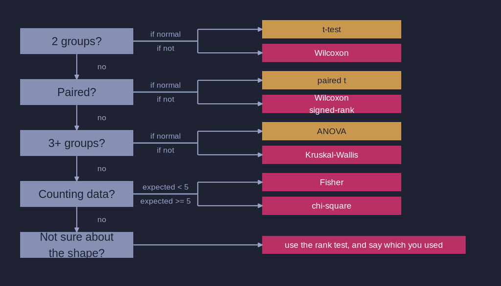

**Tip**

Write the test name in the figure legend. A reader can then check whether the claim is supported.

4. p-value & Statistical Tests

### ⚡ Q1: `p2` is right-skewed, `p3` is normal. You want to compare them. Which test?

- **A.** t-test
- **B.** Wilcoxon

4. p-value & Statistical Tests

### ✅ **B** — `p2` fails the normal check, so the rank test

- **A** the t-test **assumes** the normal distribution — `p2`’s p = 1.924505e-09 says it is not normal
- **B** Wilcoxon uses **ranks** and assumes nothing: **p = 4.502014e-12** — the gap 17.5 vs 28.07 is real

Check the shape **before** choosing the test.

4. p-value & Statistical Tests

### ⚡ Q2: Both 5-spot groups pass Shapiro-Wilk (p = 0.97 and 0.81). Which test?

- **A.** t-test
- **B.** Wilcoxon

4. p-value & Statistical Tests

### ✅ **A** — p > 0.05 is no evidence **against** normal, so the t-test is fair

- **A** both groups pass: **p = 2.275325e-06** — the gap 28 vs 16.4 is real
- **B** the rank test is not needed here, and 5 vs 5 cannot go below **p = 0.0079**

Five spots cannot **prove** normal — p > 0.05 means “not rejected”. Say n = 5 in the figure.

4. p-value & Statistical Tests

### ⚡ Q3: 30 spots — immune 2 / other 18 in control, immune 8 / other 2 in tumor. Which test?

- **A.** chi-square
- **B.** Fisher

4. p-value & Statistical Tests

### ✅ **B** — the smallest expected count is 3.33, below 5

- **A** R warns `Chi-squared approximation may be incorrect` — the expected counts 6.67, 13.33, 3.33, 6.67 include a value below 5
- **B** Fisher counts the tables exactly: **p = 2.91263e-04**

Read the expected counts, not the observed counts, to choose.

4. p-value & Statistical Tests

### ⚡ Q4: `t.test(p4, p2)` gives **p = 0.164**. What does that say?

- **A.** `p4` and `p2` are the same
- **B.** no evidence of a difference

4. p-value & Statistical Tests

### ✅ **B** — p is the chance of a gap this big **by randomness**, not proof of equality

- gap **3.1** counts
- sd **6.45** in `p4`, **1.28** in `p2`
- n = 10 vs 30
- p = 0.164
- **A** p > 0.05 does **not** show the groups are equal — it shows the data is not evidence
- **B** a gap of 3.1 against a spread of 6.45 carries little weight; report the gap, the sd, and the test name

Say **no evidence**, never “no difference”.

4. p-value & Statistical Tests

### ✅ Summary

- p = how surprising the data is, assuming no effect — p > 0.05 = not evidence
- 20,000 genes → **always** correct — Bonferroni is strict, BH controls the share of noise
- the unit is what varies independently — count patients, not spots
- 2 groups → t / Wilcoxon · paired → paired t / signed-rank · 3+ groups → ANOVA / Kruskal · counting → chi-square (expected ≥ 5) / Fisher (expected < 5)
- spread decides as much as the gap — name the test in the legend

## 5. Correlation & Regression

1. Review from Lecture 8

2. Descriptive Statistics

3. Shape, Distribution & Normality

4. p-value & Statistical Tests

**5. Correlation & Regression**

6. Statistics Practice

7. From Numbers to Figures

8. The Common Plots

9. Reading a ggplot2 Call

10. Export for Publication

11. Graphics Practice

5. Correlation & Regression

### ⚠️ The problem: two numbers per spot

Every test so far compares **groups** — control vs tumor, pre vs post, category vs category.

Some questions have **no groups**: two measurements on the same spot, and the question is whether they move together.

5. Correlation & Regression

### Pearson — a straight line

r = 0.9994, p = 4.799893e-10 — `gene_b` tracks `gene_a` almost perfectly.

- **Pearson**: straight-line relationship

5. Correlation & Regression

### Pearson visualization

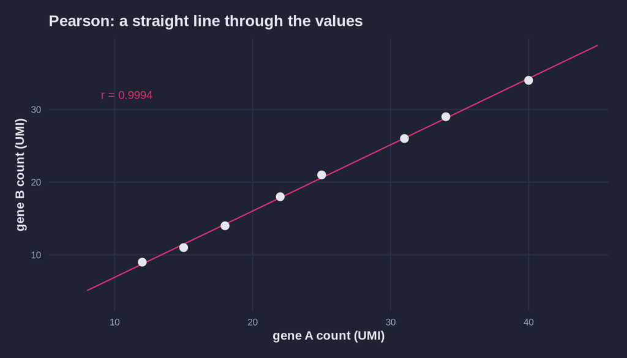

5. Correlation & Regression

### Spearman — the rank order

rho = 1, p = 4.960317e-05 — every spot keeps its order.

- **Spearman**: monotone — “as one goes up, so does the other”

5. Correlation & Regression

### Spearman visualization

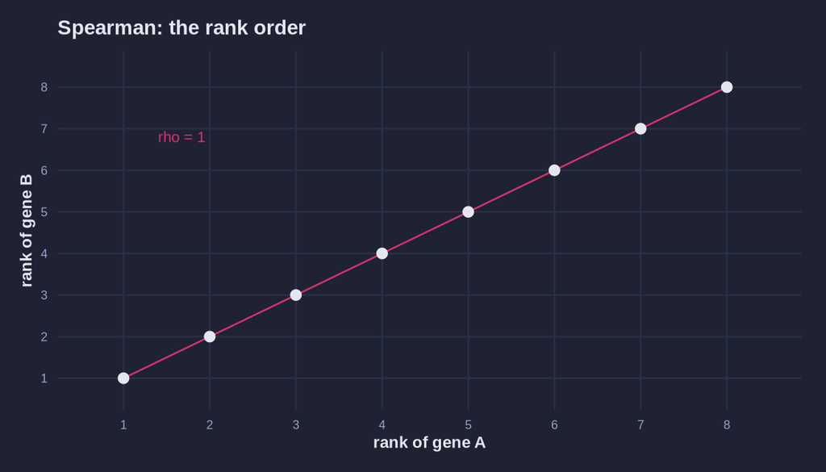

5. Correlation & Regression

### The caveat: One hot spot breaks Pearson

Pearson: r = 0.658, p = 0.076 — **not** significant. Spearman: rho = 1, p = 4.960317e-05 — unchanged.

- **Pearson** uses the **values** — one extreme count pulls the line

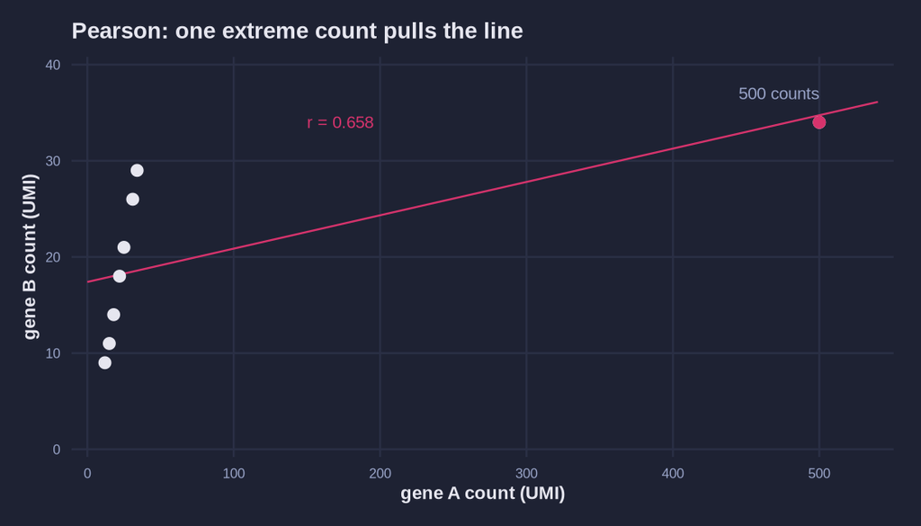

- **Spearman** uses the **ranks** — the spot is still the highest, so the ordering is untouched

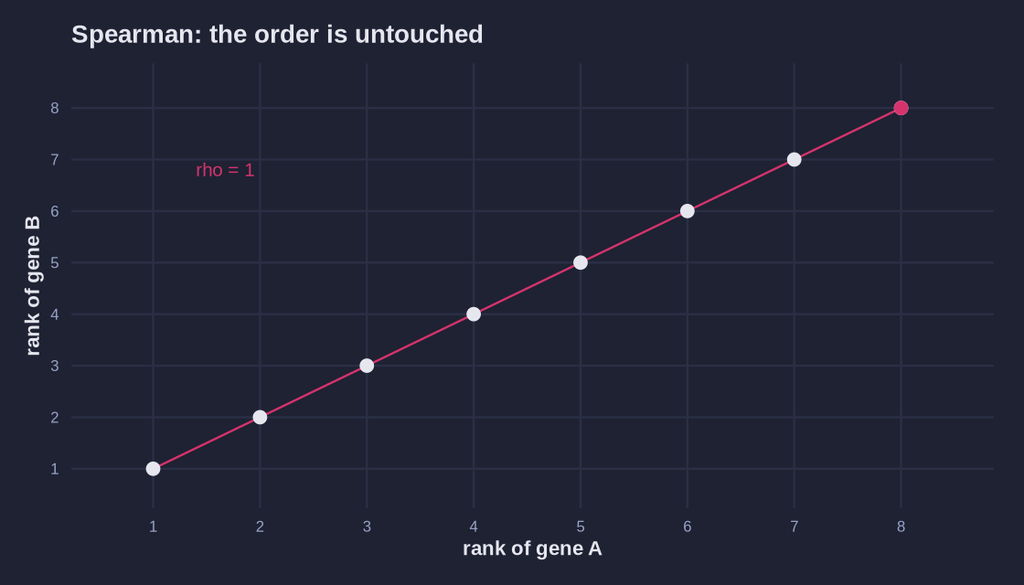

5. Correlation & Regression

### Correlation is not causation

tumor spots and normal spots can correlate in gene expression without one causing the other.

Both may be driven by a third thing: hypoxia, immune infiltration, tumor content.

[figure not shown]

Photo via X — [pbs.twimg.com/media/FAW2hMeWEAAfcvm](https://pbs.twimg.com/media/FAW2hMeWEAAfcvm?format=webp&name=large)

**Note**

Adjacent spots are *not* independent — they share tissue. A correlation between them can be a neighbourhood effect, not a biological link.

5. Correlation & Regression

### How much does one move when the other rises?

Correlation answers **how well** the two counts move together — one number, no size.

The next question is **how much**: the counts `gene_b` gains when `gene_a` rises by one. Regression draws the line and reports the slope.

5. Correlation & Regression

### Regression — a line through the data

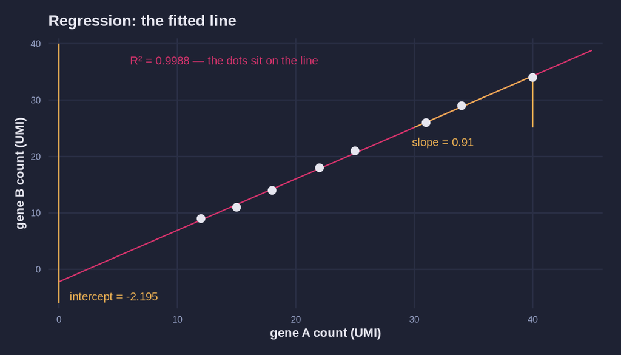

- **intercept** −2.195 — the value at 0 counts, not meaningful here
- **slope** 0.9115 — `gene_b` rises 0.91 counts per `gene_a` count, p = 4.799893e-10
- **R²** 0.9988 — the line explains 99.88% of the variation

5. Correlation & Regression

### Reading a regression

The slope is the claim. The intercept is usually plumbing. The p-value tells you the slope is real; R² tells you the line fits.

5. Correlation & Regression

### ✅ Summary

- Pearson = straight line · Spearman = ranks
- correlation ≠ causation
- regression = slope (the claim) + p (the confidence) + R² (the fit)
- spatial data is not independent — say what the correlation means

## 6. Statistics Practice

1. Review from Lecture 8

2. Descriptive Statistics

3. Shape, Distribution & Normality

4. p-value & Statistical Tests

5. Correlation & Regression

**6. Statistics Practice**

7. From Numbers to Figures

8. The Common Plots

9. Reading a ggplot2 Call

10. Export for Publication

11. Graphics Practice

6. Statistics Practice

### 🖥️ Colab Session — Statistics Practice

Same as Lectures 5, 6 and 8: the practice runs in **Google Colab**, R runtime, nothing to install.

- Upload `counts_annotated.tsv` — Lecture 6’s count matrix
- Open `lecture-09_statistics_practice.ipynb`, set `Runtime → Change runtime type → R`
- Run the cells in order: `Runtime → Run All`

The notebook takes the deck’s tools to the real matrix: descriptive stats, shape check, per-gene tests, BH correction, correlation and regression.

6. Statistics Practice

### counts → QC → statistics → figure

The goal is **not the p-value**. It is **explaining your data to another person** — and a **figure** does that faster than any table.

## 7. From Numbers to Figures

1. Review from Lecture 8

2. Descriptive Statistics

3. Shape, Distribution & Normality

4. p-value & Statistical Tests

5. Correlation & Regression

6. Statistics Practice

**7. From Numbers to Figures**

8. The Common Plots

9. Reading a ggplot2 Call

10. Export for Publication

11. Graphics Practice

7. From Numbers to Figures

### 🎬 Previously on statistics…

- **Center & spread**: `median` resists outliers, `mean` absorbs them; report `mean ± sd`, keep `var` for models.
- **Check shape first**: `shapiro.test()` & Q-Q plot decide the test — normal $\rightarrow$ parametric, skewed $\rightarrow$ rank test.
- **Test biological units**: compare patients, not pooled spots (no pseudoreplication) — $t$ / ANOVA vs Wilcoxon / Kruskal.
- **Multiple testing**: 20,000 genes give $\sim 1,000$ fluke hits at $p < 0.05 \rightarrow$ control FDR with **Benjamini-Hochberg (BH)**.
- **Associate & model**: Pearson $r$ (linear) vs Spearman $\rho$ (ranks); `lm()` gives the slope and fit ($R^2$).

**Tip**

Statistics tells us *something moved* — figures show **what moved and in which direction**.

7. From Numbers to Figures

### 🧾 We’ve done the statistics… What now?

| gene | Tumor | Control | log2FC | sd | p |
| --- | --- | --- | --- | --- | --- |
| `MKI67` | 482.5 | 3.0 | 7.33 | 25.1 | `7.8e-5` |
| `CDKN2A` | 190.0 | 2.0 | 6.57 | 10.7 | `9.4e-5` |
| `EPCAM` | 323.8 | 6.0 | 5.75 | 15.5 | `6.1e-5` |
| `KRT19` | 209.0 | 4.0 | 5.71 | 9.6 | `5.0e-5` |
| `CDH1` | 151.0 | 5.0 | 4.92 | 8.3 | `8.7e-5` |
| `VIM` | 262.0 | 8.0 | 5.03 | 11.1 | `4.2e-5` |
| `PTPRC` | 6.0 | 214.5 | `−5.16` | 0.8 | `3.6e-5` |
| `CD3E` | 2.6 | 96.8 | `−5.22` | 0.5 | `2.7e-5` |
| `CD8A` | 1.9 | 70.0 | `−5.24` | 0.3 | `6.0e-5` |
| `GAPDH` | 997.8 | 1010.8 | `−0.02` | 27.6 | **1.0** |

**Important**

**Raw data is meaningless**, and statistics on raw data **is still raw data.**

7. From Numbers to Figures

### 📊 Draw it — 10 genes, 2 groups, one glance

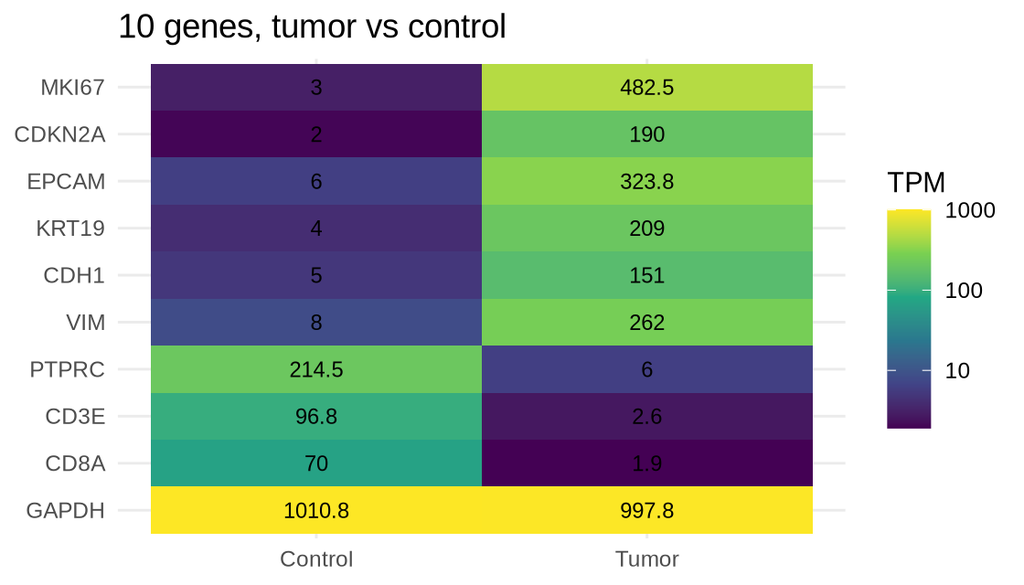

**Important**

Statistics says *something moved*. The figure says **what moved, and in which direction** — a pattern no p-value column can hold. That is why we draw. **The how starts here.**

7. From Numbers to Figures

### 🖼️ Every figure is code-generated

The figure you just saw is a **file** on disk.

7. From Numbers to Figures

### ⚙️ Five perks of code-generated figures

- **repeatable** — rerun the script, the same figure.
- **editable** — change the data or one `aes()`, the figure redraws
- **exact** — size, dpi, colours are numbers in code, not a mouse drag
- **batchable** — one loop over 20 genes, one style for all 20
- **trackable** — code is text, so `git` sees every change

7. From Numbers to Figures

### 🧰 Tools you’ll need

- **ggplot2**: draws figures from a data frame — dots, lines, bars, tiles
- **dplyr**: picks, filters, and summarises columns
- **tidyr**: reshapes between wide and long
- **ggridges**: ridgeline plots
- **RColorBrewer**: colour palettes
- … depending on what you plan to do…

7. From Numbers to Figures

### 📖 Ask yourself 3 questions before you draw.

1. **what data?** — the first argument
2. **what is drawn?** — the geometry: dots, lines, bars, boxes, tiles
3. **what maps where?** — which column becomes x, y, colour, size

**Tip**

You do not have to remember the syntax to read it. Every call states its own data, geometry, and mapping, in that order.

## 8. The Common Plots

1. Review from Lecture 8

2. Descriptive Statistics

3. Shape, Distribution & Normality

4. p-value & Statistical Tests

5. Correlation & Regression

6. Statistics Practice

7. From Numbers to Figures

**8. The Common Plots**

9. Reading a ggplot2 Call

10. Export for Publication

11. Graphics Practice

8. The Common Plots

### A. General plots

- **scatter, line** — relationship and trend
- **bar, box, histogram, density** — one column of numbers, and groups
- **dot plot, stacked bars, Venn, UMAP/tSNE, correlation matrix** — composition, overlap, and pairs of measures

**Note**

One slide per plot type: the figure, the question it answers, and the numbers it is built from.

8. The Common Plots

### 🧾 Base graphics: the four shapes you meet first

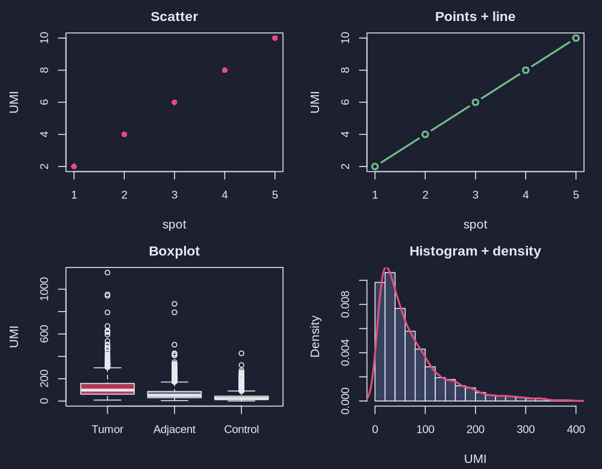

- **scatter** — does y move with x?
- **line** — how does y change across x?
- **boxplot** — centre, spread, outliers, per group
- **histogram** — how one column is spread

8. The Common Plots

### ⚪ Scatter and line: relationship and trend

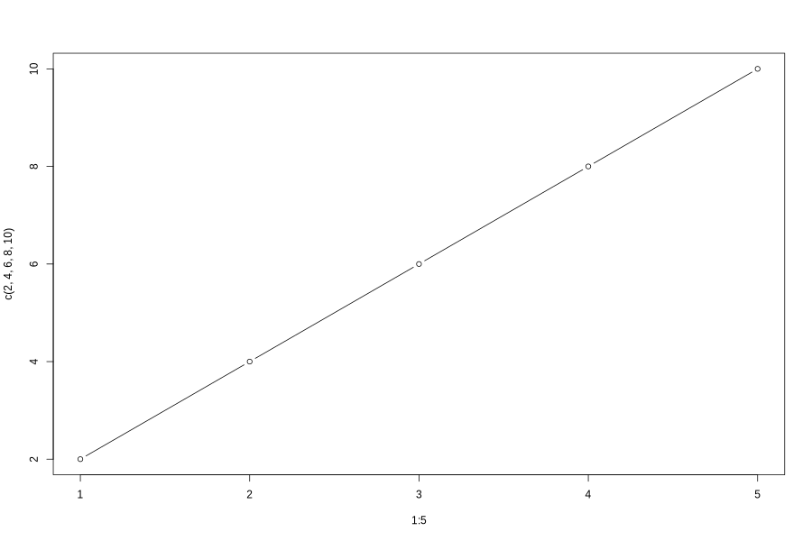

```r
plot(1:5, c(2, 4, 6, 8, 10), type = "b")
```

- **scatter → relationship**: one dot per pair, does y move with x
- **line → trend**: the same dots joined in order, the shape is the trend
- join only what is ordered: spot 1 → 5, time 1 → 12

8. The Common Plots

### 📊 Bar plots: one value per category

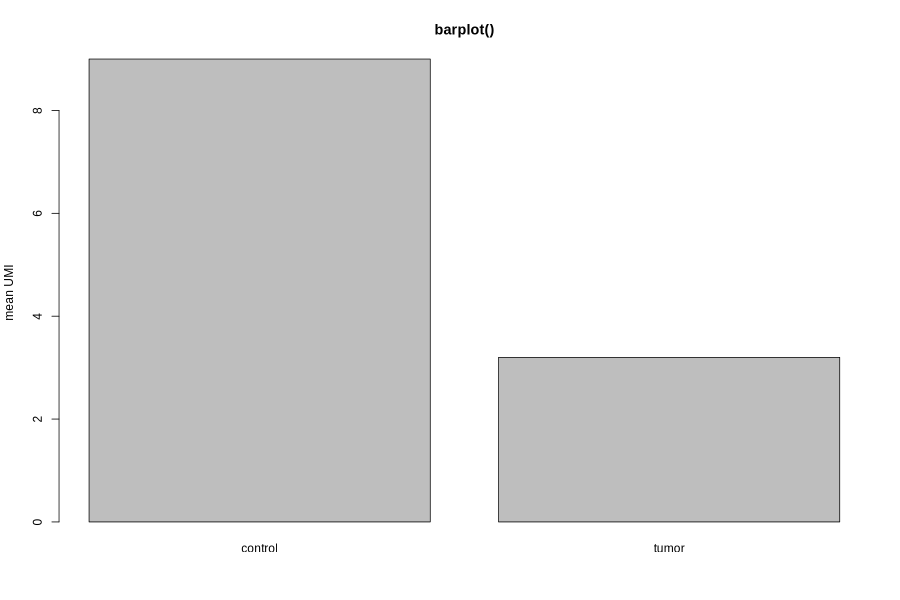

- **bar → one value per category**: the height **is** the value — say which (mean, median, count, sum)
- The bar hides the spread behind it

**Note**

Bar plots show one number per group. Ask what the number is: mean, median, count, sum. The caption has to say, and the axis label usually does not.

8. The Common Plots

### 📊 Bars with error bars: the bar, plus the spread

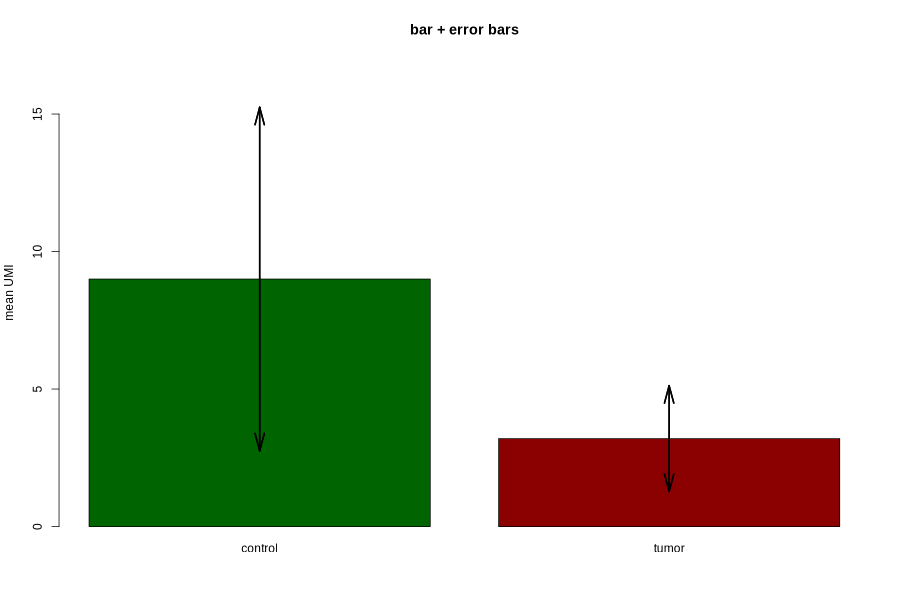

- **bar + error bar → one value per category, with its spread**: bar is the centre, arms are the spread (sd, SE, or CI — say which)
- Overlapping arms mean the gap is not clean

**Note**

An error bar is the smallest honest fix for a hidden spread. What it is — sd, standard error, confidence interval — has to be in the caption.

8. The Common Plots

### 📊 Box plots: centre, spread, and outliers per group

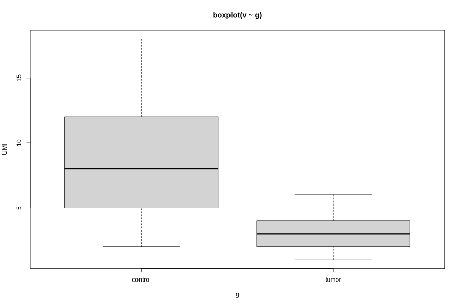

- **box → centre, spread, outliers**: one box per group, all on one axis
- The box keeps the spread visible, per group

**Note**

Read the axis before the shape. A boxplot of UMI and a boxplot of p-values look the same and mean nothing alike.

8. The Common Plots

### 📊 Histograms: how one column is spread

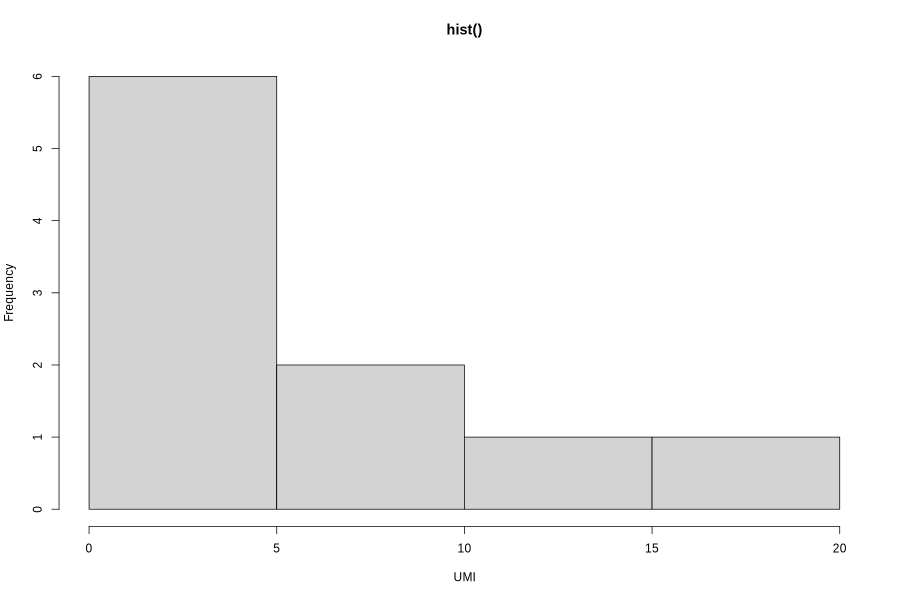

- **histogram → spread of one column**: binned — the bars are **counts**, not values
- The shape shows where the mass sits

**Note**

A histogram has one axis that is not the data: the y-axis is the bin count. Change `breaks` and the shape changes — the data did not.

8. The Common Plots

### 📈 Density and ridgeline: the shape, without bins

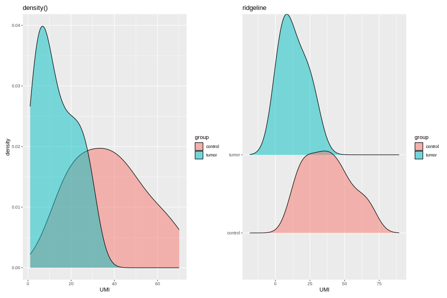

- **density / ridgeline → shape without bins**: smoothed curve of one column; stacked when per group
- The curve shows where the mass sits, not just the centre

**Note**

A histogram depends on `breaks`, a density on the bandwidth. Both are choices about the picture, not properties of the data.

8. The Common Plots

### ⚪ Dot plot: every spot, one dot

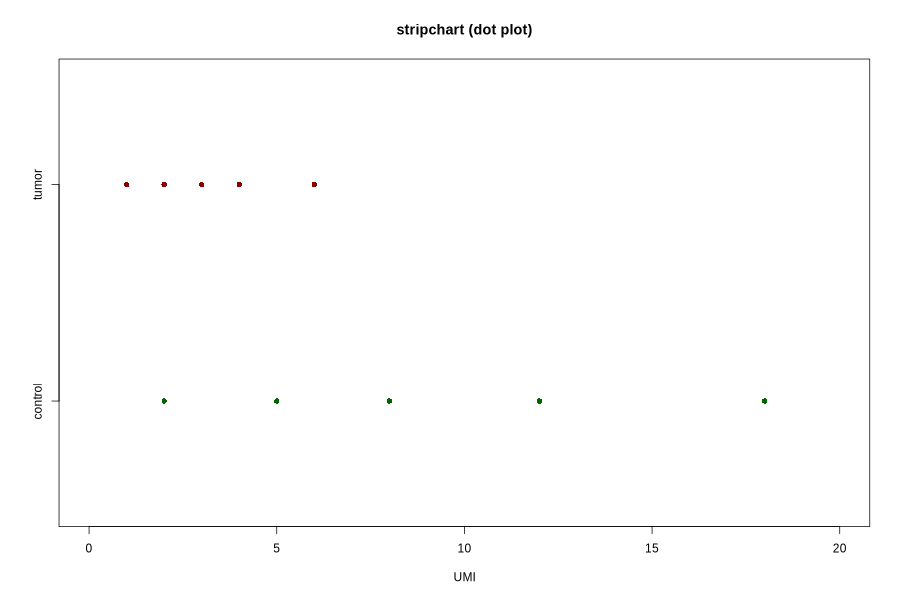

- **dot plot → every value, one dot**: one dot per observation, no bins
- Works for tens of points; at thousands the dots blur into a curve

**Note**

A dot plot is a histogram that refuses to bin. It works for tens of points; at thousands the pile becomes a curve.

8. The Common Plots